# Figures for manuscript

2024-09-27

## H<sub>2</sub>O<sub>2</sub> concentration

**Figure 1 - H<sub>2</sub>O<sub>2</sub> optimization** We evaluated how the concentration of H<sub>2</sub>O<sub>2</sub> affected the oxidation of MBTH/DMAB using two concentrations of MnP (0.005 U and 0.008 U, 10 µl in the 200 µl reaction).

We found that both too low and too high concentrations were sub-optimal for the reactions and that a lower concentration (2.5 mM) than we usually have been using (5 mM) seemed to be optimal for our assay conditions

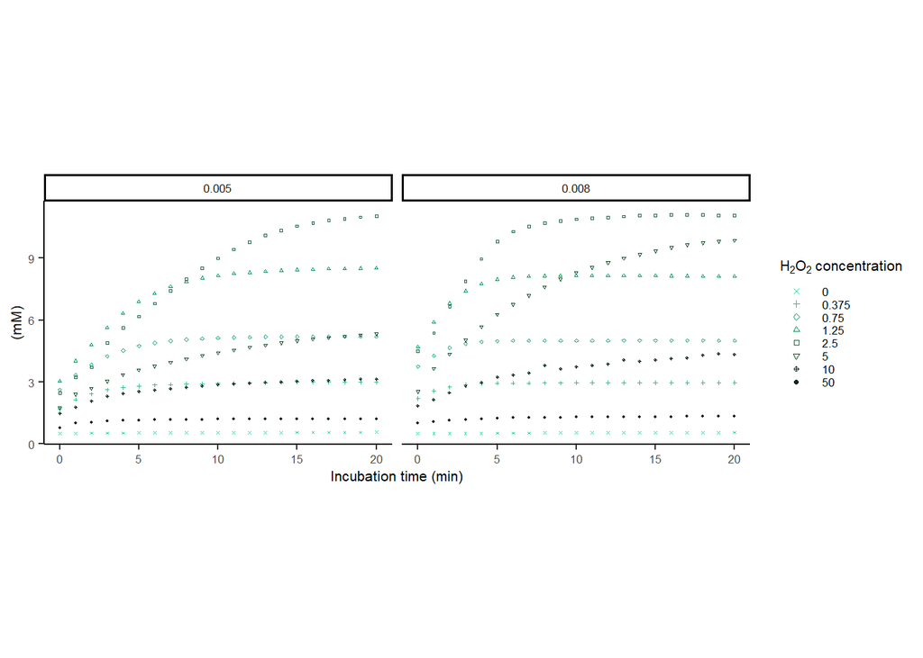

## Mn-dependency

We tested the assumption that the MnSO<sub>4</sub> and EDTA controls could be used to distinguish between Mn-dependent and independent oxidation of the four different substrates (ABTS, DMP, L-DOPA, MBTH/DMAB). All assay conditions were identical except for the dye-forming substrate. We ran incubations with either recombinant manganese peroxidase (MnP) from *Phanerochaete* or a versitile peroxidase from horseradish (HoP). In these assays, we used a lower H<sub>2</sub>O<sub>2</sub> concentration (2.5 mM) than we have used previously (5 mM in Kyaschenko protocol).

**Figure 2 - MnP and HoP** Absorbance plotted over time (30 min incubation) of all substrates and either MnP or HoP. Concentrations of MnP and HoP seem to be balanced for the MBTH/DMAB assay (similar absorbance). However, the other substrates seem to diverge in their specificity for the different enzymes. DMP and L-DOPA are easily oxidized by MnP but not by HoP while ABTS is rapidly oxidised by HoP but not by MnP.

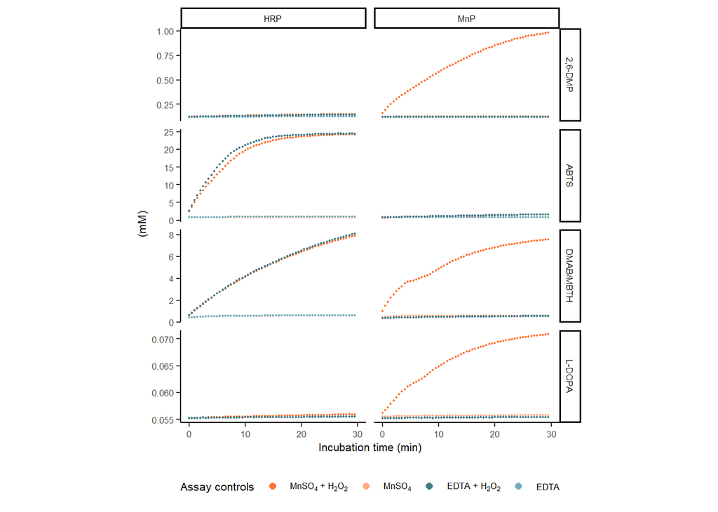

## Homogenization test

Here, we tested the hypothesis that more intense sample homogenization would impact the assay by releasing internal peroxidases to the extract. We grew *Hypholoma fasiculare* on needles for about a month and tested the difference between three levels of extraction intensity. - Soaking in acetate buffer - Vortex shaking in acetate buffer (no visible tears in the mycelium) - Complete disruption of mycelium (UltraTurrax)

More interestingly, the increase in absorbance in the “B + H<sub>2</sub>O<sub>2</sub>” treatment for homogenised samples suggests that some other type of peroxidase was released. I’m not sure whether the *Hypholoma* produces extracellular non-Mn dependent peroxidases but if it does, we should be able to observe an increase in absorbance in “B + H<sub>2</sub>O<sub>2</sub>” also in the shaken sample. I therefore assume that some internal peroxidases were released when we homogenized the mycelium. It is a bit difficult to interpret the significance of the non-Mn dependent peroxidases in relation to MnP in this assay since recovery of MnP also increased in that treatment.

**Figure 3** Absorbance plotted over time (15 min). Different extraction intensities and all four substrates. Points are mean values of 4 technical replicates from 3 biological replicates.

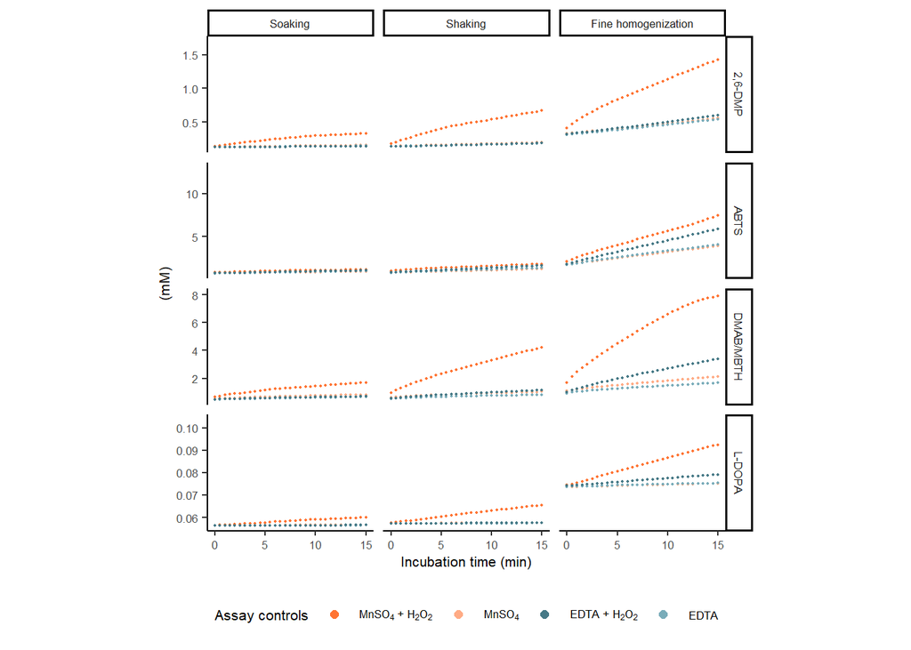

We also did a non-replicated get an idea about how much enzyme could still be extracted after an initial round of shaking the plates. We therefore added more acetate buffer to the plates that had been shaken and tried the different levels of extraction intensity. It is clear that there is a lot of enzyme remaining after the first extraction round. This would mean that the extraction method should be standardized, otherwise semi-quantitative measurements would be difficult.

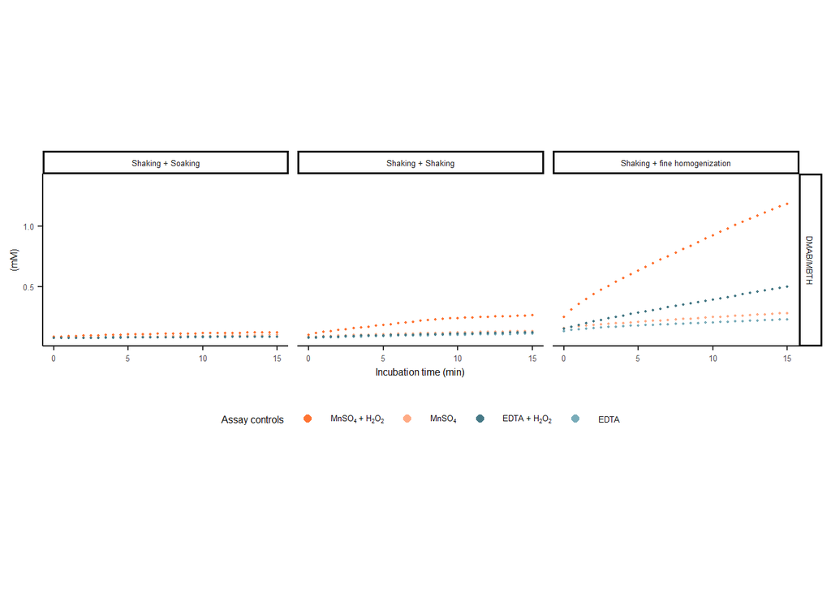